# Exploratory data analysis, dimension reduction, and latent variable models

Paulina Duda

#### Dependencies

```r
library(tidyverse)
library(patchwork)
library(RColorBrewer)
library(gplots)
library(devtools)
library(data.table)
library(broom)
library(Biobase)
library(limma)
library(edge)
library(genefilter)
library(GEOquery)
library(qvalue)
library(sva)
library(jackstraw)
library(irlba)
library(Rtsne)
library(corpcor)
library(Seurat)
library(SeuratData)
library(bladderbatch)
library(gridExtra)
library(cluster)
```

#### Load the `ExpressionSet` data

Make sure to apply log2 transformation and remove genes whose expression levels are below a threshold, 10:

```r
con = url("http://bowtie-bio.sourceforge.net/recount/ExpressionSets/bottomly_eset.RData")
load(file=con)
close(con)
edata <- as.matrix(exprs(bottomly.eset))
dim(edata)
```

```
[1] 36536    21
```

```r
edata[1:5,1:5]
```

```
                   SRX033480 SRX033488 SRX033481 SRX033489 SRX033482
ENSMUSG00000000001       369       744       287       769       348
ENSMUSG00000000003         0         0         0         0         0
ENSMUSG00000000028         0         1         0         1         1
ENSMUSG00000000031         0         0         0         0         0
ENSMUSG00000000037         0         1         1         5         0
```

```r
edata <- edata[rowMeans(edata) > 10, ]
edata <- log2(as.matrix(edata) + 1)
```

> Homework Problem 1: Make one heatmap of the aforementioned Bottomly data with the following options: a) both rows and columns are clustered, b) show a dendrogram only on the columns., and c) scale in the column direction.

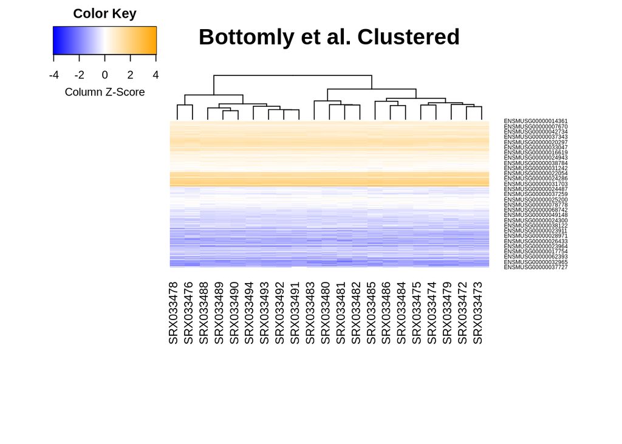

```r
my_palette <- colorRampPalette(c("blue", "white", "orange"))(n = 299)
# png("Duda_problem1.png",height=700,width=700)
heatmap.2(edata,
          main = "Bottomly et al. Clustered", # heat map title
          notecol="black",      # change font color of cell labels to black
          density.info="none",  # turns off density plot inside color legend
          trace="none",         # turns off trace lines inside the heat map
          margins =c(12,9),     # widens margins around plot
          col=my_palette,       # use on color palette defined earlier
          dendrogram="col",     # only draw a row dendrogram
          scale = "col",
          Colv=TRUE,
          Rowv=TRUE)
```

```r
# dev.off()
```

#### Singular value decomposition (SVD)

Scaling the edata matrix and compute SVD.

```r
edata <- t(scale(t(edata), scale=FALSE, center=TRUE))
svd.out <- svd(edata)
```

#### Scatter plots using right Singular Vectors (Principal Components)

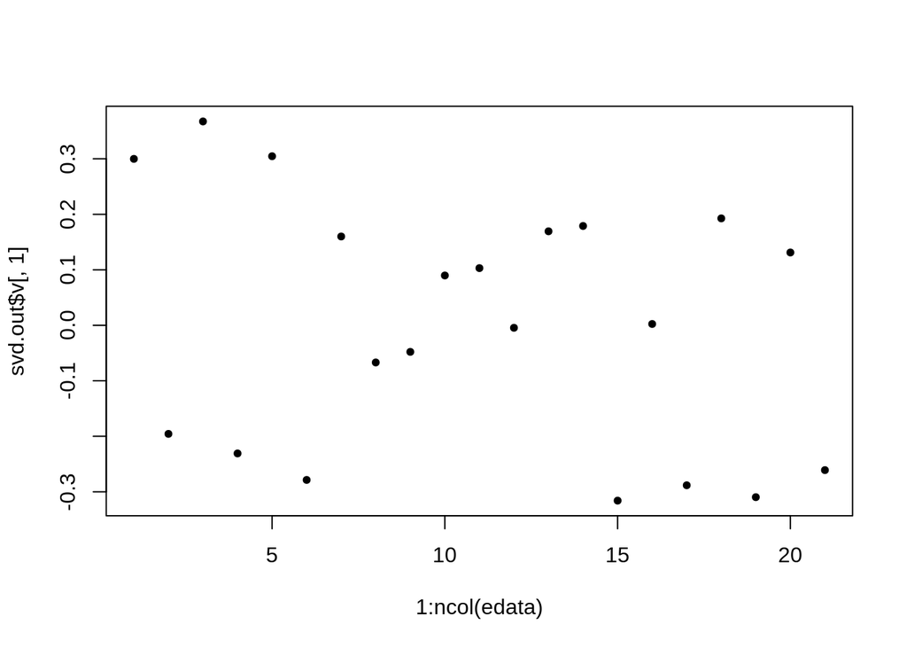

```r
plot(1:ncol(edata), svd.out$v[,1],pch=20)
```

We can make a scatter plot of the top 2 PCs. And using the meta data, we can color each data point accordingly.

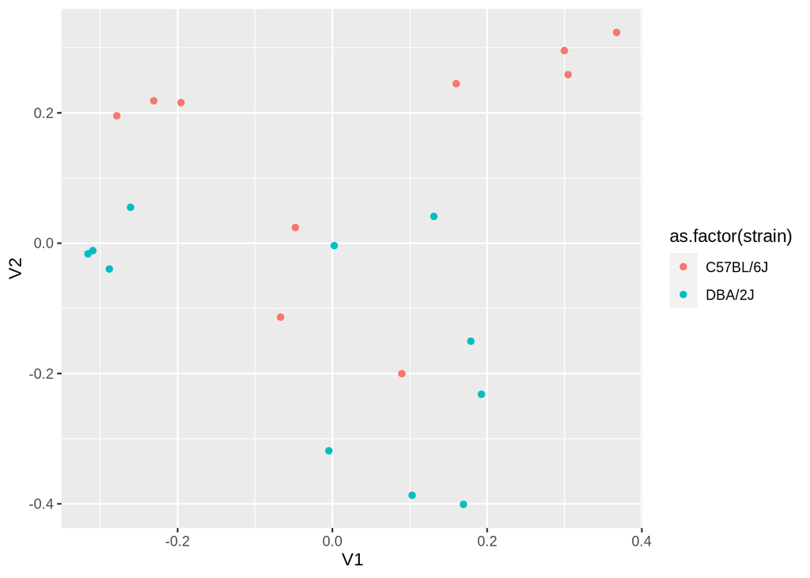

```r
PCv = data.table(svd.out$v,pData(bottomly.eset))
ggplot(PCv) + geom_point(aes(x=V1, y=V2, col=as.factor(strain)))
```

> Homework Problem 2: Explore different combinations of PCs in scatter plots while coloring the data points by the genetic strains. Find a combination of PCs that separate the strains well. Send only one scatterplot.

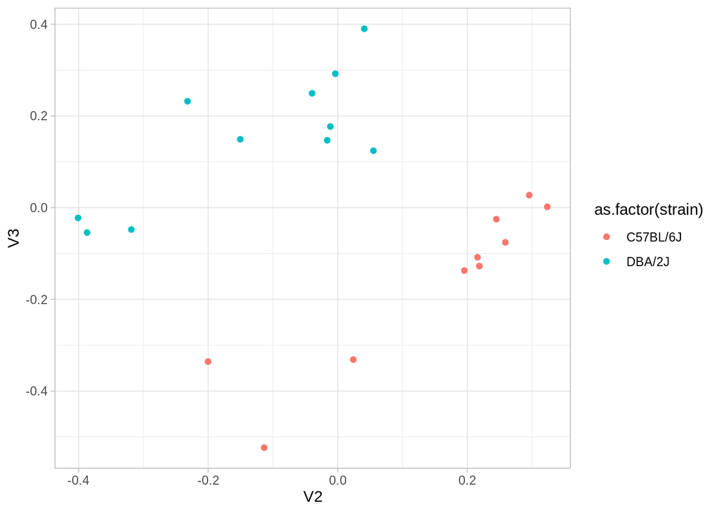

```r
ggplot(PCv) + geom_point(aes(x=V2, y=V3, col=as.factor(strain))) + theme_light()
```

```r
ggsave('Duda_problem2.pdf', plot = last_plot(), dpi = 300)
```

#### Boxplots and violin plots

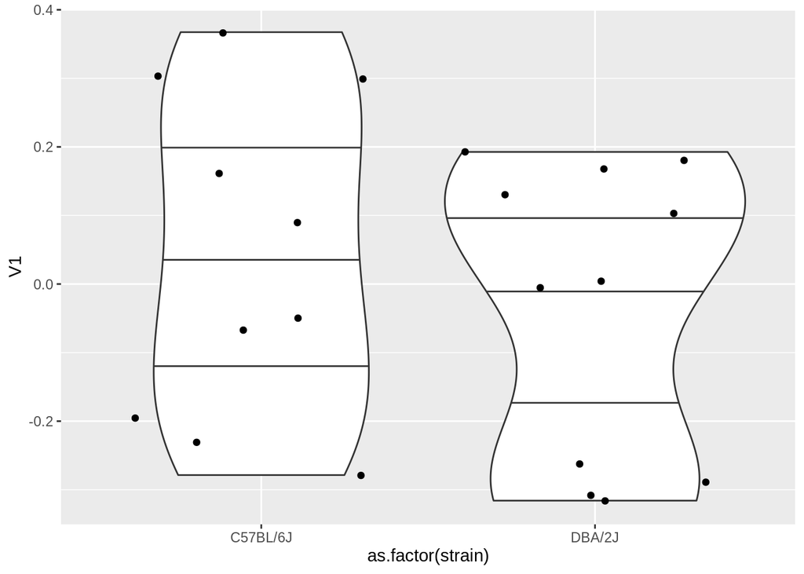

```r
ggplot(PCv) + geom_violin(aes(x=as.factor(strain), y=V1),draw_quantiles = c(0.25, 0.5, 0.75)) +
              geom_jitter(aes(x=as.factor(strain), y=V1))
```

#### Visualize Left Singular Vectors (Loadings)

> Homework Problem 3: Make a scatter plot of the top 2 left singular vectors.

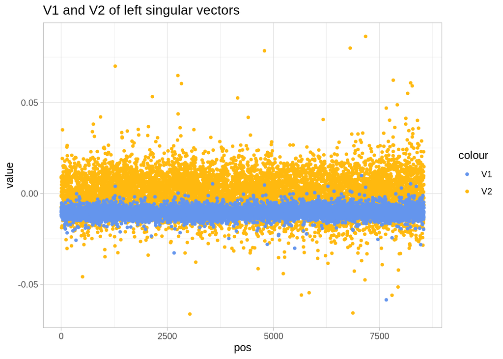

```r
PCu = data.table(svd.out$u,pData(bottomly.eset))
ggplot(PCu) +
        geom_point(aes(x=seq_along(PCu$V2), y=V2, colour="darkgoldenrod1"), size=1) +
        geom_point(aes(x=seq_along(PCu$V1), y=V1, colour="cornflowerblue"), size=1) +
        xlab("pos") + ylab("value") + labs(title="V1 and V2 of left singular vectors", size = 15) +
        scale_colour_manual(labels = c("V1", "V2"), values = c("cornflowerblue", "darkgoldenrod1")) +
        theme_light()
```

```r
ggsave('Duda_problem3.pdf', plot = last_plot(), dpi = 300)
```

> Homework Problem 4: Make one figure that contains violin plots of the top 5 left singular vectors (loadings).

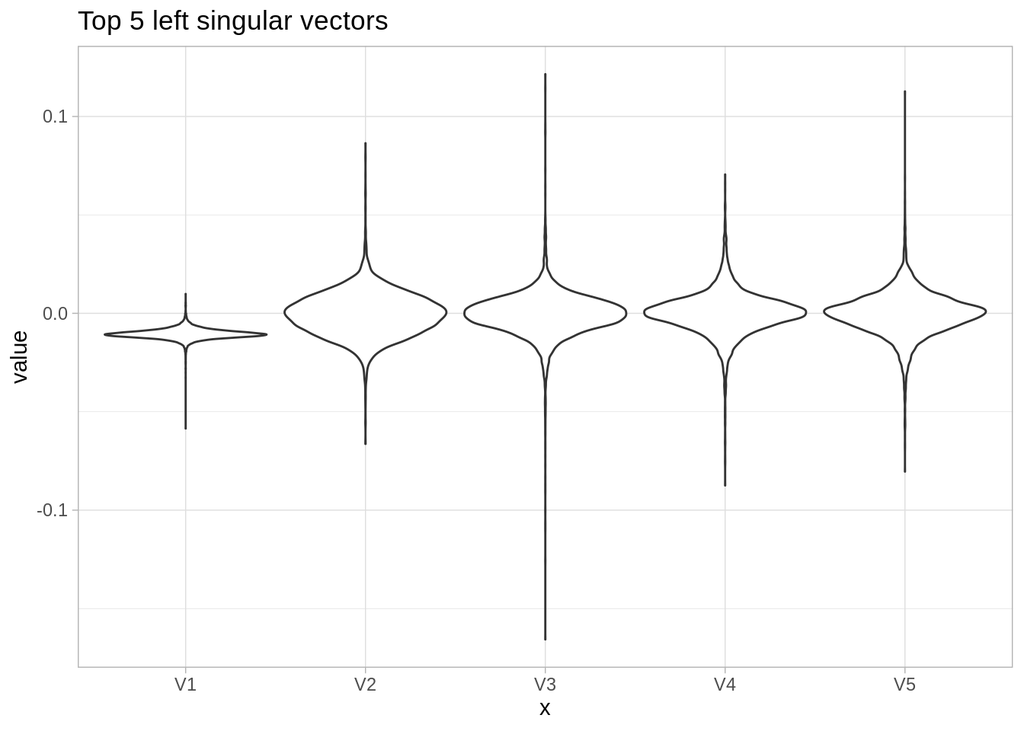

```r
ggplot(PCu) +
        geom_violin(aes(x="V1", y=V1)) +
        geom_violin(aes(x="V2", y=V2)) +
        geom_violin(aes(x="V3", y=V3)) +
        geom_violin(aes(x="V4", y=V4)) +
        geom_violin(aes(x="V5", y=V5)) +
        ylab("value") + labs(title="Top 5 left singular vectors") + theme_light()
```

```r
ggsave('Duda_problem4.pdf', plot = last_plot(), dpi=300)
```

#### t-Distributed Stochastic Neighbor Embedding (t-SNE)

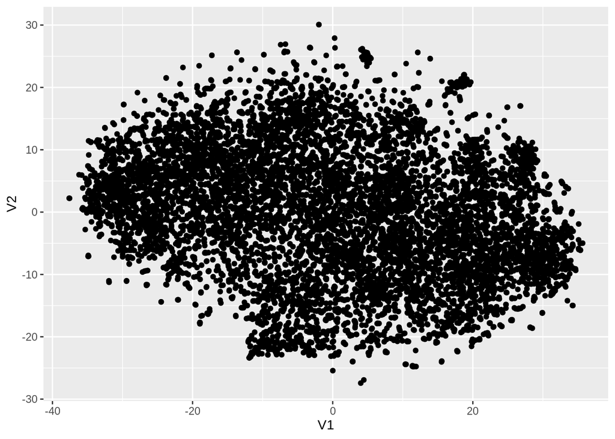

```r
set.seed(1)
tsne_out <- Rtsne(edata,pca=TRUE,perplexity=30)
tsne_out = data.table(tsne_out$Y)
ggplot(tsne_out) + geom_point(aes(x=V1, y=V2))
```

> Homework Problem 5: Cluster the genes (rows) using K-means clustering (function kmeans()) on the original data, with k=5 clusters. Then, create a 2-dimensional t-SNE projection (as done previously) while using the 5 clusters to color the data points corresponding to genes.

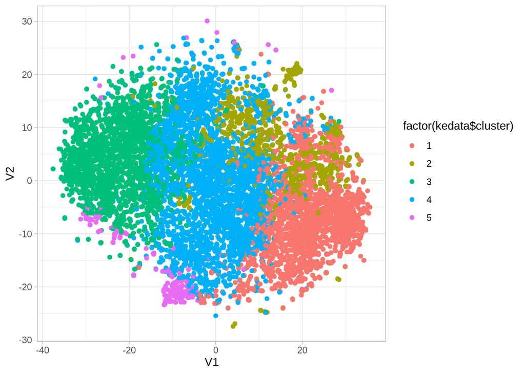

```r
kedata <- kmeans(edata, centers=5)
ggplot(tsne_out) + geom_point(aes(x=V1, y=V2, color=factor(kedata$cluster))) + theme_light()
```

```r
ggsave('Duda_problem5.pdf', plot = last_plot(), dpi=300)
```